# Homework 1c- Intro to R

Due Friday Feb 7th 11:59 PM

## Introduction

Before you begin, you will need to install R and Rstudio. If you are familiar with R and already have it installed, you can skip to the problem sets.

For any activity in R I need a record that you have successfully implemented the code on your own device. That means I want you to turn in a file with your code (.RMD or.QMD file) and your output (.PDF). We will go over in class how to create and turn in both types of files. See instructions [here](https://quarto.org/docs/output-formats/pdf-basics.html) about how to render your document as a pdf. As we are in a transition phase as a program from RMarkdown to Quarto, I am comfortable with you using either. If you are new to both, I strongly recommend using Quarto. They operate extremely similarly, but Quarto offers some extra flexibility that may aid you in more advanced courses.

For this assignment (and this assignment only) I’ve also provided a template QMD file you can use to write your answers and use as a guide for future homeworks.

## Install R and R Studio

If you have not already, you will need to first install R and RStudio (you can use the RStudio serve if need be, but my reccomendation is to download on your own computer if possible). Lab 1 from our shared course SDS 100 includes information on how to install R and RStudio for the following software:

- Set up instructions for [Apple MacBooks](https://smithcollege-sds.github.io/sds100/setup_mac.html)
- Set up instructions fo [Windows Computers](https://smithcollege-sds.github.io/sds100/setup_windows.html)
- Set up instructions for [Chromebooks](https://smithcollege-sds.github.io/sds100/setup_server.html)

### Part 1- Install Packages

We will be using a number of packages in the class throughout the semester. We first will use Devtools to enable R to grab packages from Github, and then install other packages. To install a package you need to run the code `install.packages("PACKAGENAME")` (with the package name being changed to whatever the package is). For example if we wanted to install Devtools, we can use the following code below.

```r
install.packages("devtools")
```

You only need to install the package one time. after that, we can use the code `library(PACKAGENAME)` to load the installed packages anytime you want to use them. In all submissions, you could include a chunk of code that loads the required packages (but no others).

To prove that you have successfully installed each package include the code below in a chunk for when you knit your final document. Install the following packages: devtools, ggplot2, tidyverse, rio an Stat2Data. Note you only have to install the package once, so only include `library(packagename)` in your final code.

```r
library(ggplot2)
library(devtools)
library(tidyverse)
library(rio)
library(Stat2Data)
```

**1. Include a chunk of code that loads each of the 5 mentioned packages.**

## Part 2 - Financial incentives for weight loss

To get you started, run the following command to load the data from Chapter 0 in your textbook. This needs to be in a chunk for your final submission otherwise R won’t know wehre to get the data from.

```r
data(WeightLossIncentive)
```

This command instructs R to load some data: You should see that the workspace area in the upper righthand corner of the RStudio window now lists a data set called `WeightLossIncentive` that has 38 observations on 3 variables. As you interact with R, you will create a series of objects. Sometimes you load them as we have done here, and sometimes you create them yourself as the byproduct of a computation or some analysis you have performed.

You can read more details about this data but using the `?` command:

```r
?WeightLossIncentive
```

We can view the data by typing its name into the console. However printing the whole dataset in the console is not that useful. Instead we can see the top 6 cases with the following command. Type the following line under `data(WeightLossIncentive)` in your lab report by clicking `Enter` after the `)`. Then run it.

```r
head(WeightLossIncentive)
```

```
  WeightLoss   Group Month7Loss
1       12.5 Control       -2.0
2       12.0 Control        7.0
3        1.0 Control       19.5
4       -5.0 Control       -0.5
5        3.0 Control       -1.5
6       -5.0 Control      -10.0
```

One advantage of RStudio is that it comes with a built-in data viewer. Click on the name `WeightLossIncentive` in the *Environment* pane (upper right window) that lists the objects in your workspace. This will bring up an alternative display of the data set in the *Data Viewer* (upper left window). You can close the data viewer by clicking on the `x` in the upper lefthand corner.

What you should see are four columns of numbers, each row representing a different person: the first entry in each row is simply the row number (an index we can use to access the data from individual people if we want), the second is the amount of weight loss, and the third is the experimental group to which the person was assigned. The fourth is the 7 month follow-up. Each case is a person in this dataset. Use the scrollbar on the right side of the console window to examine the complete data set.

Note that the row numbers in the first column are not part of the `WeightLossIncentive` data. R adds them as part of its printout to help you make visual comparisons. You can think of them as the index that you see on the left side of a spreadsheet. In fact, the comparison to a spreadsheet will generally be helpful. R has stored the weightloss incentive data in a kind of spreadsheet or table called a *data frame*.

You can see the dimensions (number of rows, the cases, and number of columns, the variables) of this data frame as well as the names of the variables and the first few observations by typing it under `glimpse(WeightLossIncentive)` and then running it:

```r
glimpse(WeightLossIncentive)
```

```
Rows: 38
Columns: 3
$ WeightLoss <dbl> 12.5, 12.0, 1.0, -5.0, 3.0, -5.0, 7.5, -2.5, 20.0, -1.0, 2.…
$ Group      <fct> Control, Control, Control, Control, Control, Control, Contr…
$ Month7Loss <dbl> -2.0, 7.0, 19.5, -0.5, -1.5, -10.0, 0.5, 5.0, 8.5, 18.0, 16…
```

We can see that there are 38 observations and 3 variables in this dataset. At this point, you might notice that many of the commands in R look a lot like functions from math class; that is, invoking R commands means supplying a function with some number of arguments. The `glimpse` command, for example, took a single argument, the name of a data frame.

## Some Exploration

Let’s start to examine the data a little more closely. We can access the data in a single column of a data frame separately using a command like

```r
WeightLossIncentive$WeightLoss
```

```
 [1]  12.5  12.0   1.0  -5.0   3.0  -5.0   7.5  -2.5  20.0  -1.0   2.0   4.5
[13]  -2.0 -17.0  19.0  -2.0  12.0  10.5   5.0  25.5  24.0   8.0    NA  15.5
[25]    NA  21.0   4.5  30.0   7.5  10.0  18.0   5.0  -0.5  27.0   6.0  25.5
[37]  21.0  18.5
```

This command will only show the amount of weight the participants lost during the study. The dollar sign basically says “go to the data frame that comes before me, and find the variable that comes after me”.

**2. What command would you use to extract just the groups that participants were assigned to? Include a chunk with that command**

Notice that the way R has printed these data is different. When we looked at the complete data frame, we saw 38 rows, one on each line of the display. These data are no longer structured in a table with other variables, so they are displayed one right after another. Objects that print out in this way are called *vectors*; they represent a set of numbers. R has added numbers in [brackets] along the left side of the printout to indicate locations within the vector. This can help you keep track of your cases.

### Data visualization

R has some powerful functions for making graphics. We can create a simple plot of the amount of weight lost by participants with the command

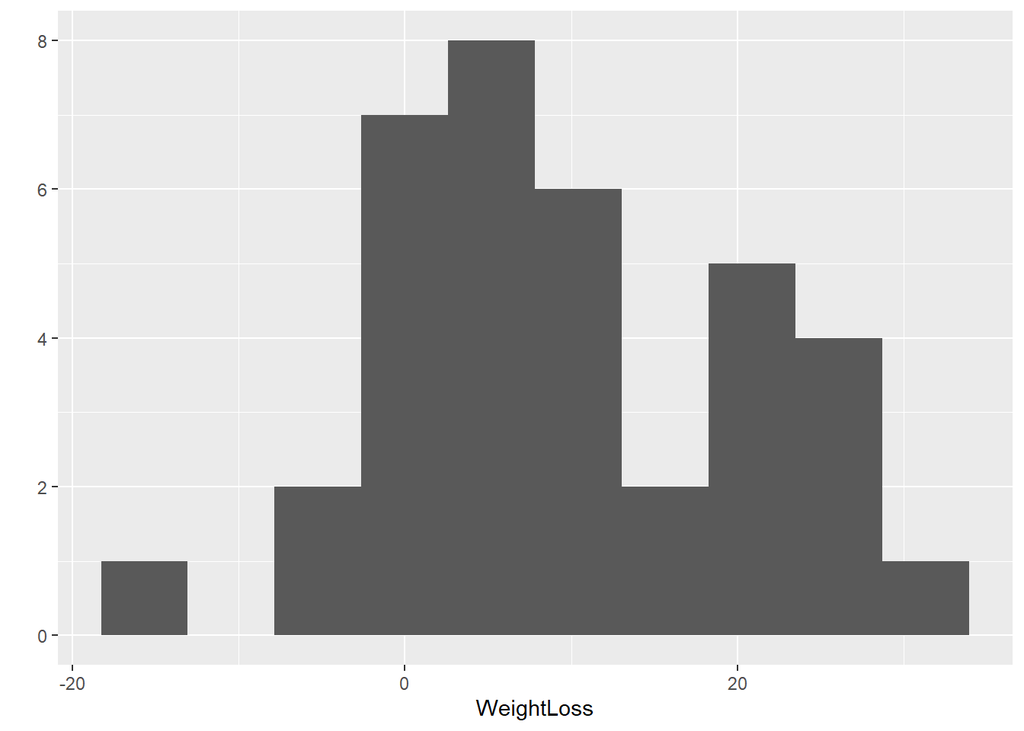

```r
#try typing this directly into the console and pressing enter
qplot(x = WeightLoss, data = WeightLossIncentive, bins = 10)
```

The `qplot()` function (meaning “quick plot”) considers the type of data you have provided it and makes the decision to visualize it with a histogram. The plot should appear under the code chunk. Notice that the command above again looks like a function, this time with three arguments separated by commas. The first two arguments in the `qplot()` function specify the variable for the x-axis and the name of the data set where they can be found. The third specifies the number of bins for the histogram. Try changing the number of bins (e.g., 12 bins, 3 bins, 27 bins).

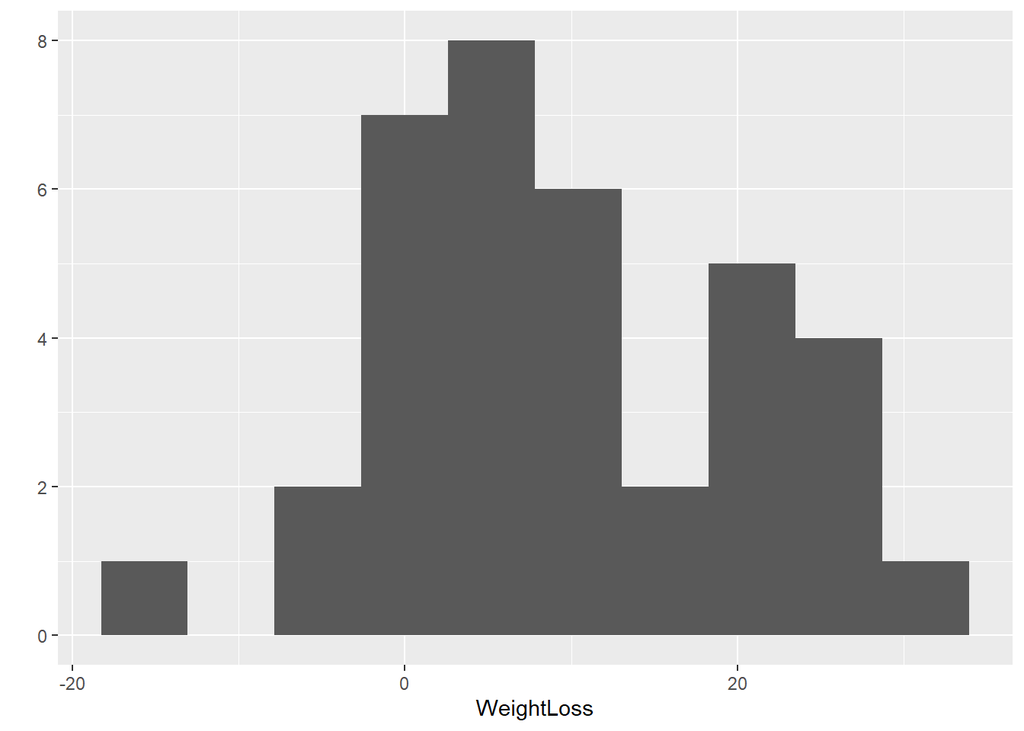

```r
#Create a chunk and put this code in as part of your answer
qplot(x = WeightLoss, data = WeightLossIncentive, bins = 10)
```

**3. Does the distribution of weight loss appear normal (i.e., approximately bell-shaped)? How would you describe it (in terms of modality and skew, for example)? (To ensure that your homework is comprehensive, be sure to include the code needed to make the plot as well as your written interpretation. Hint: The code you need is displayed above, you just need to put it in a chunk)** *

Thankfully, R documents all of its functions extensively. To read what a function does and learn the arguments that are available to you, just type in a question mark followed by the name of the function that you’re interested in. Try the following.

```r
#type into the console
?qplot
```

Notice that the help file replaces the plot in the lower right panel. You can toggle between plots and help files using the tabs at the top of that panel.

### Summary Statistics

Now, suppose we want to calculate the sample size, average weight loss, and standard deviation of weight loss for the two groups (incentive and control). We can use the `filter()`, `group_by()` and `summarize()` functions.

```r
# Start recording in your exercise 3 chunk from here
WeightLossIncentive %>%
  filter(!is.na(WeightLoss)) %>%
  group_by(Group) %>%
  summarize(group_n = n(),
            group_mean = mean(WeightLoss),
            group_sd = sd(WeightLoss))
```

```
# A tibble: 2 × 4
  Group     group_n group_mean group_sd
  <fct>       <int>      <dbl>    <dbl>
1 Control        19       3.92     9.11
2 Incentive      17      15.7      9.41
```

The `%>%` operator (now the `|>` on quarto) is called the **piping** operator. It takes the output of the previous expression and pipes it into the first argument of the function in the following one. To continue our analogy with mathematical functions, `x %>% f(y)` is equivalent to `f(x, y)`.

**A note on piping:** Note that we can read these three lines of code as the following:

“Take the `WeightLossIncentive` dataset and **pipe** it into the `filter` function. Only keep those cases where the `WeightLoss` variable is not (`!`) missing (`is.na()`). We do this to keep our code simple later on. More on working with missing data later on in the semester. The we pipe this complete data into the `group_by` function. Group the `WeightLossIncentive` data set by `Group` then **pipe** that grouped dataset into the `summarize` function. Summarize that grouped dataset by calculating the sample size (`n() function`) a mean (`mean()` function) and a standard deviation (`sd()` function) for each group. Note that the `n()` function is just empty. This might look weird, but it’s what we want!

We can also make a side-by-side boxplot to visualize the weight loss by group. Again we’ll use the `qplot` function, but this time the variable `Group` will be on the x-axis and the variable `WeightLoss` will be on the y-axis. We’ll add a fourth argument, `gemo = "boxplot"` to tell the `qplot` function that we want boxplots. Note that if you take away the `geom` argument then `qplot` will make a parallel dotplot.

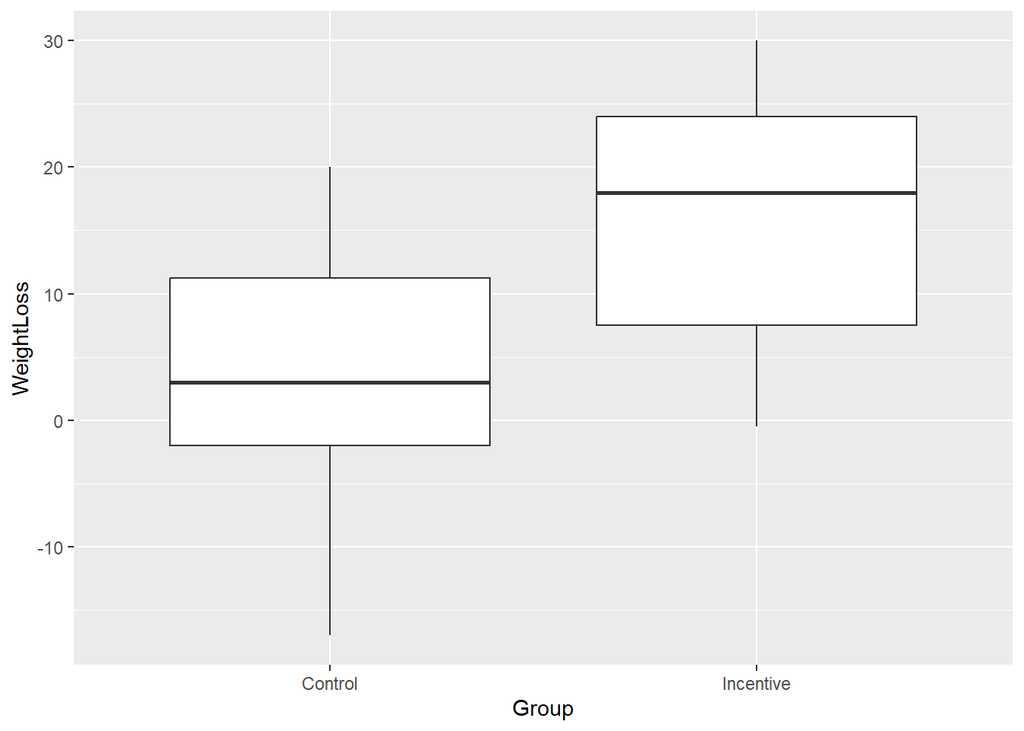

```r
qplot(x = Group, y = WeightLoss, data = WeightLossIncentive, geom = "boxplot")
```

We can also go a step further and compute a t-test for the difference between `Group` means to assess if the difference we see in the means in statistically significant.

```r
t.test(WeightLoss ~ Group, data = WeightLossIncentive)
```

```
    Welch Two Sample t-test

data:  WeightLoss by Group
t = -3.7982, df = 33.276, p-value = 0.0005889
alternative hypothesis: true difference in means between group Control and group Incentive is not equal to 0
95 percent confidence interval:
 -18.05026  -5.46058
sample estimates:
  mean in group Control mean in group Incentive
               3.921053               15.676471
```

And we can assess the normality of scores in each group with a facet-wrapped histogram. We’ll use the `+` operator to add a layer to our `qplot`. We use the function `facet_wrap()` and inside we put our grouping variable `Group` with a `~` in front of it.

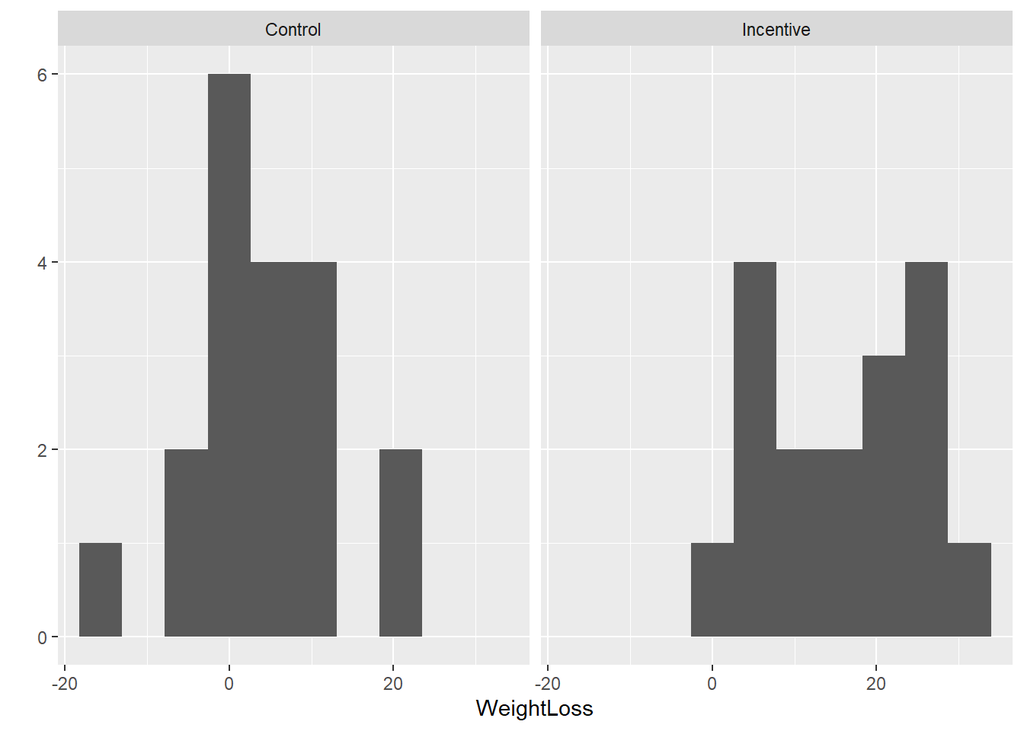

```r
qplot(x = WeightLoss, data = WeightLossIncentive, bins = 10) +
  facet_wrap(~Group)
```

**4. Which group lost more weight based on the means? Which group has more variability in their weight loss?**

Make sure to include a chunk producing the summary table.

### More visualization

We can also make a scatterplot to visualize the relationship between the amount of weight lost during the study versus the amount of weight loss reported at the 7 month follow-up.

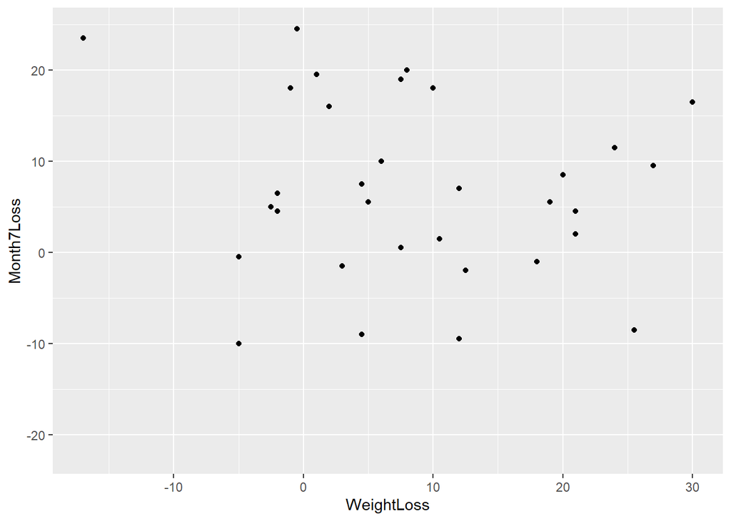

```r
qplot(x = WeightLoss, y = Month7Loss, data = WeightLossIncentive)
```

We can even separate the point on the scatterplot by `Group` by adding the `color = Group` argument.

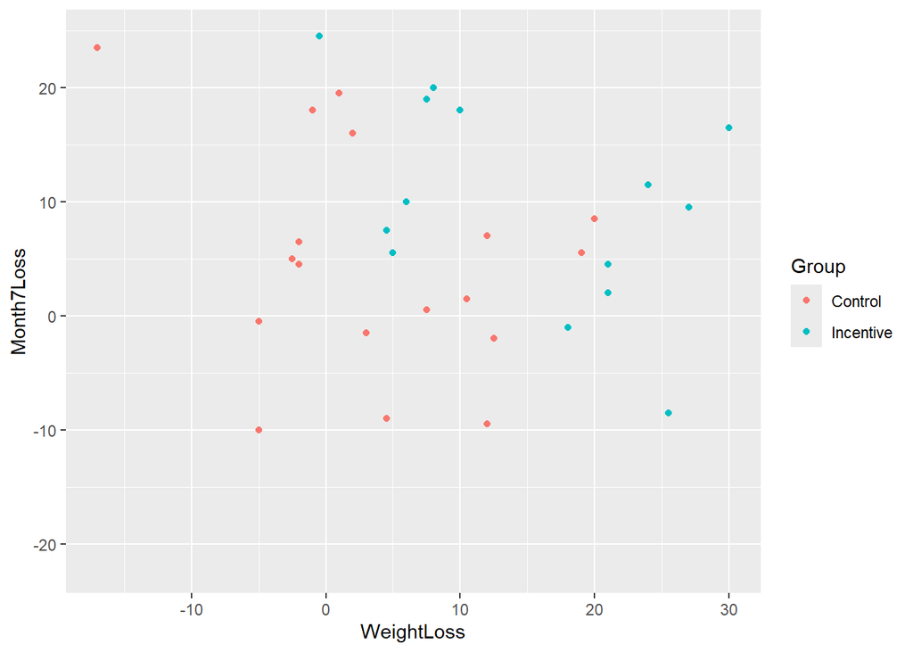

```r
qplot(x = WeightLoss, y = Month7Loss, data = WeightLossIncentive, color = Group)
```

**5. Do you notice any patterns in these scatterplots? What might that pattern (or lack of pattern) mean, for the weight loss study? For this answer, no code is needed, but I’m looking for a few sentences to answer each part of this question**

## Submission instructions

In your submission (.QMD and rendered PDF) you should include you answer to the 5 prompts, with each clearly labeled. When using code make sure it is in a chunk. All submissions must be on Moodle.

## Resources for learning R and working in RStudio

That was a short introduction to R and RStudio, but we will provide you with more functions and a more complete sense of the language as the course progresses.

In this course we will be using R packages called `dplyr` for data wrangling and `ggplot2` for data visualization. If you are googling for R code, make sure to also include these package names in your search query. For example, instead of googling “scatterplot in R”, google “scatterplot in R with ggplot2”.

These cheatsheets may come in handy throughout the semester:

- [RMarkdown cheatsheet](https://www.rstudio.com/wp-content/uploads/2016/03/rmarkdown-cheatsheet-2.0.pdf)
- [Data wrangling cheatsheet](http://www.rstudio.com/wp-content/uploads/2015/02/data-wrangling-cheatsheet.pdf)
- [Data visualization cheatsheet](http://www.rstudio.com/wp-content/uploads/2015/12/ggplot2-cheatsheet-2.0.pdf)

Chester Ismay has put together a resource for new users of R, RStudio, and R Markdown [here](https://ismayc.github.io/rbasics-book). It includes examples showing working with R Markdown files in RStudio recorded as GIFs.

Note that some of the code on these cheatsheets may be too advanced for this course, however majority of it will become useful throughout the semester.